# Modularity, CR, and Aging

Megan McMahon

10/4/2019

**Main**

1 - Whole brain modularity changes with age

1.2 - Young adults - whole brain modularity increases with age, and no significant relationship with interdaily stability, intradaily stability, or relative amplitude

1.3 - Older adults - whole brain modularity decreases with age, but is better explained by relative amplitude (lower relative amplitude is related to decreased modularity)

2 - Age group differences in modularity not statistically significant

[3] No effect of IS or IV on modularity

4 No significant relationship between modularity and cognitive measures

## Group Differences

- No significant age group difference in whole brain modularity

```r
t.test(wb_modularity_x ~ group, data = d)
```

```
##
##  Welch Two Sample t-test
##
## data:  wb_modularity_x by group
## t = -0.21015, df = 74.784, p-value = 0.8341
## alternative hypothesis: true difference in means is not equal to 0
## 95 percent confidence interval:
##  -0.03674557  0.02973284
## sample estimates:
## mean in group Young Adults mean in group Older Adults
##                  0.4112881                  0.4147945
```

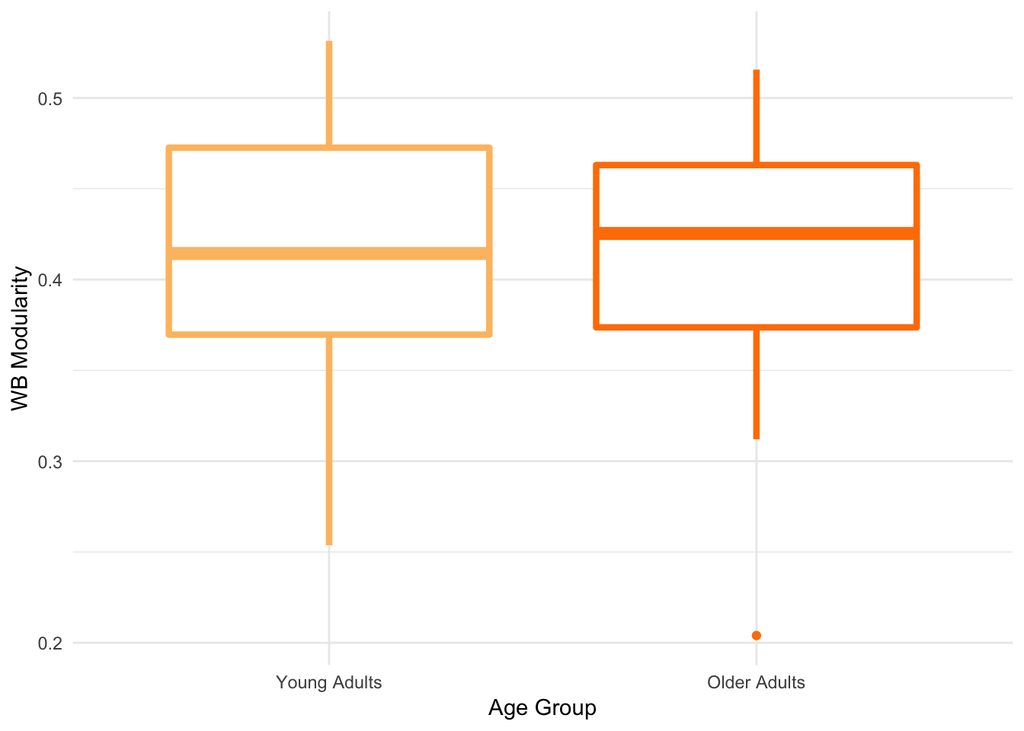

```r
ggplot(data = d) +
  geom_boxplot(aes(x = group, y = wb_modularity_x, group = group, color = group), size=1.5, show.legend = FALSE) +
  theme_minimal() +
  scale_color_manual(values = brewer.pal(8, "Paired")[7:8]) +
  xlab('Age Group') + ylab('WB Modularity')
```

## Age Effect

- Whole brain modularity increases with age among young adults, but decrease with age among older adults

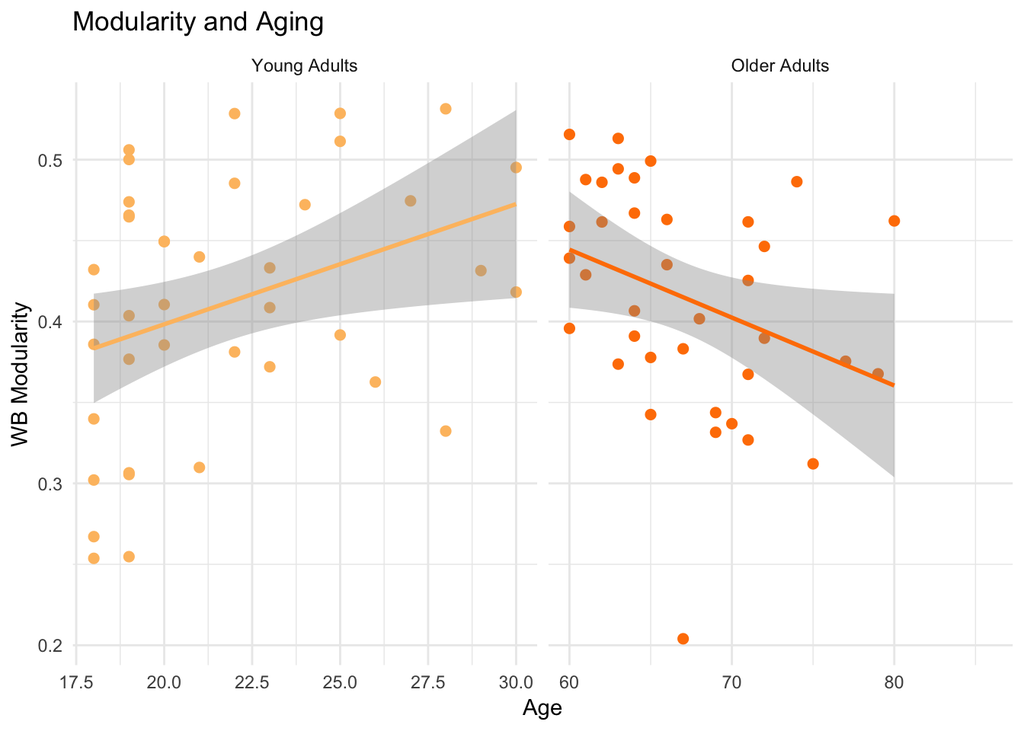

```r
ggplot(data = d) +
  ggtitle('Modularity and Aging') +
  geom_point(aes(x = age, y = wb_modularity_x, group = group, color = group), size=2, show.legend = FALSE) +
  facet_wrap(. ~ group, scales = 'free_x', labeller = label_value) +
  stat_smooth(aes(x = age, y = wb_modularity_x, group = group, color = group), method = 'lm', formula = y ~ x, se = TRUE, fullrange = FALSE, show.legend = FALSE) +
  theme_minimal() +
  scale_color_manual(values = brewer.pal(8, "Paired")[7:8]) +
  xlab('Age') + ylab('WB Modularity')
```

## Young Adults

Whole brain modularity increases with age, and no significant relationship with interdaily stability, intradaily stability, or relative amplitude

```r
lm1 <- lm(wb_modularity_x ~ age , data = d[d$group == 'Young Adults',])
summary(lm1) # * .0247
```

```
##
## Call:
## lm(formula = wb_modularity_x ~ age, data = d[d$group == "Young Adults",
##     ])
##
## Residuals:
##      Min       1Q   Median       3Q      Max
## -0.13613 -0.05000  0.01238  0.05650  0.11532
##
## Coefficients:
##             Estimate Std. Error t value Pr(>|t|)
## (Intercept) 0.249731   0.070069   3.564   0.0010 **
## age         0.007428   0.003176   2.338   0.0247 *
## ---
## Signif. codes:  0 '***' 0.001 '**' 0.01 '*' 0.05 '.' 0.1 ' ' 1
##
## Residual standard error: 0.07392 on 38 degrees of freedom
##   (20 observations deleted due to missingness)
## Multiple R-squared:  0.1258, Adjusted R-squared:  0.1028
## F-statistic: 5.468 on 1 and 38 DF,  p-value: 0.02473
```

```r
lm2 <- lm(wb_modularity_x ~ age + RA , data = d[d$group == 'Young Adults',])
summary(lm2) # NS
```

```
##
## Call:
## lm(formula = wb_modularity_x ~ age + RA, data = d[d$group ==
##     "Young Adults", ])
##
## Residuals:
##      Min       1Q   Median       3Q      Max
## -0.13985 -0.04988  0.01157  0.05406  0.11792
##
## Coefficients:
##             Estimate Std. Error t value Pr(>|t|)
## (Intercept) 0.172529   0.095536   1.806   0.0791 .
## age         0.007432   0.003160   2.352   0.0241 *
## RA          0.091836   0.077714   1.182   0.2449
## ---
## Signif. codes:  0 '***' 0.001 '**' 0.01 '*' 0.05 '.' 0.1 ' ' 1
##
## Residual standard error: 0.07353 on 37 degrees of freedom
##   (20 observations deleted due to missingness)
## Multiple R-squared:  0.1576, Adjusted R-squared:  0.1121
## F-statistic: 3.461 on 2 and 37 DF,  p-value: 0.04189
```

```r
lm2 <- lm(wb_modularity_x ~ age + IS , data = d[d$group == 'Young Adults',])
summary(lm2) # NS
```

```
##
## Call:
## lm(formula = wb_modularity_x ~ age + IS, data = d[d$group ==
##     "Young Adults", ])
##
## Residuals:
##      Min       1Q   Median       3Q      Max
## -0.13631 -0.04990  0.01217  0.05669  0.11584
##
## Coefficients:
##              Estimate Std. Error t value Pr(>|t|)
## (Intercept)  0.251200   0.093535   2.686   0.0108 *
## age          0.007413   0.003281   2.259   0.0298 *
## IS          -0.002854   0.118335  -0.024   0.9809
## ---
## Signif. codes:  0 '***' 0.001 '**' 0.01 '*' 0.05 '.' 0.1 ' ' 1
##
## Residual standard error: 0.07491 on 37 degrees of freedom
##   (20 observations deleted due to missingness)
## Multiple R-squared:  0.1258, Adjusted R-squared:  0.07856
## F-statistic: 2.663 on 2 and 37 DF,  p-value: 0.08311
```

```r
lm2 <- lm(wb_modularity_x ~ age + IV , data = d[d$group == 'Young Adults',])
summary(lm2) # NS
```

```
##
## Call:
## lm(formula = wb_modularity_x ~ age + IV, data = d[d$group ==
##     "Young Adults", ])
##
## Residuals:
##      Min       1Q   Median       3Q      Max
## -0.13574 -0.05103  0.01266  0.05675  0.11818
##
## Coefficients:
##              Estimate Std. Error t value Pr(>|t|)
## (Intercept)  0.252616   0.075370   3.352  0.00186 **
## age          0.007539   0.003363   2.242  0.03106 *
## IV          -0.005794   0.050804  -0.114  0.90982
## ---
## Signif. codes:  0 '***' 0.001 '**' 0.01 '*' 0.05 '.' 0.1 ' ' 1
##
## Residual standard error: 0.0749 on 37 degrees of freedom
##   (20 observations deleted due to missingness)
## Multiple R-squared:  0.1261, Adjusted R-squared:  0.07887
## F-statistic:  2.67 on 2 and 37 DF,  p-value: 0.0826
```

```r
lm2 <- lm(wb_modularity_x ~ group * RA , data = d)
summary(lm2) # NS
```

```
##
## Call:
## lm(formula = wb_modularity_x ~ group * RA, data = d)
##
## Residuals:
##      Min       1Q   Median       3Q      Max
## -0.16770 -0.04748  0.01921  0.05028  0.11370
##
## Coefficients:
##                      Estimate Std. Error t value Pr(>|t|)
## (Intercept)           0.33433    0.06435   5.195 1.92e-06 ***
## groupOlder Adults    -0.06949    0.09598  -0.724    0.471
## RA                    0.09165    0.07544   1.215    0.229
## groupOlder Adults:RA  0.08837    0.11274   0.784    0.436
## ---
## Signif. codes:  0 '***' 0.001 '**' 0.01 '*' 0.05 '.' 0.1 ' ' 1
##
## Residual standard error: 0.07139 on 70 degrees of freedom
##   (54 observations deleted due to missingness)
## Multiple R-squared:  0.08087,    Adjusted R-squared:  0.04148
## F-statistic: 2.053 on 3 and 70 DF,  p-value: 0.1143
```

```r
outlierTest(lm1)
```

```
## No Studentized residuals with Bonferonni p < 0.05
## Largest |rstudent|:
##     rstudent unadjusted p-value Bonferonni p
## 24 -1.946378           0.059233           NA
```

```r
durbinWatsonTest(lm1)
```

```
##  lag Autocorrelation D-W Statistic p-value
##    1      -0.1759628      2.348399    0.28
##  Alternative hypothesis: rho != 0
```

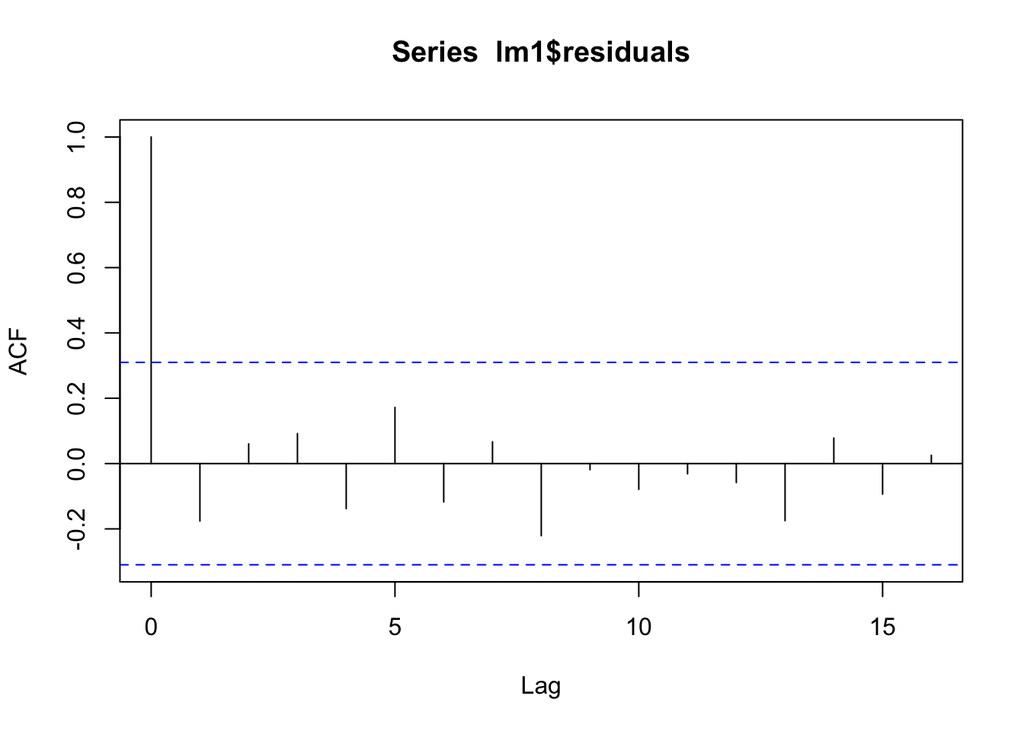

```r
plot(acf(lm1$residuals))
```

```r
shapiro.test(lm1$residuals) # p = 0.1406
```

```
##
##  Shapiro-Wilk normality test
##
## data:  lm1$residuals
## W = 0.95778, p-value = 0.1406
```

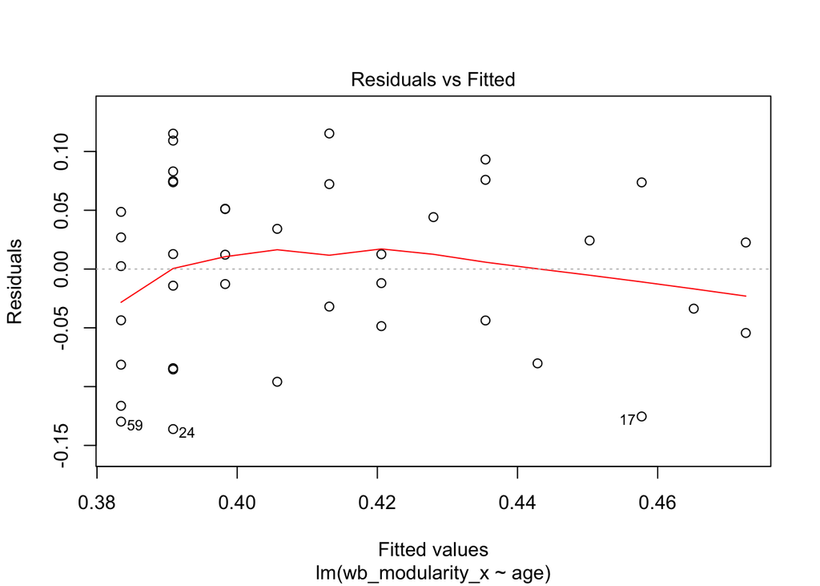

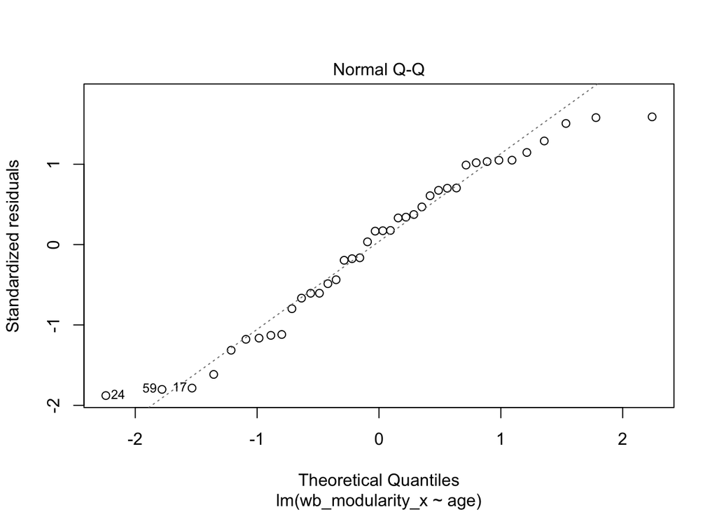

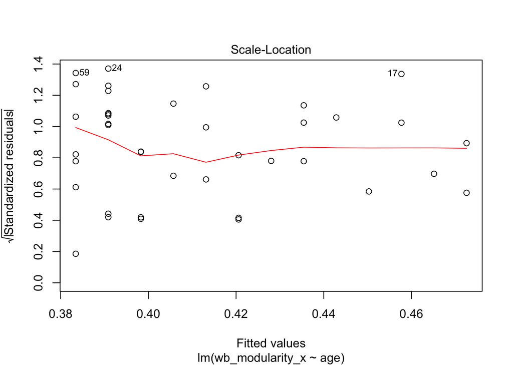

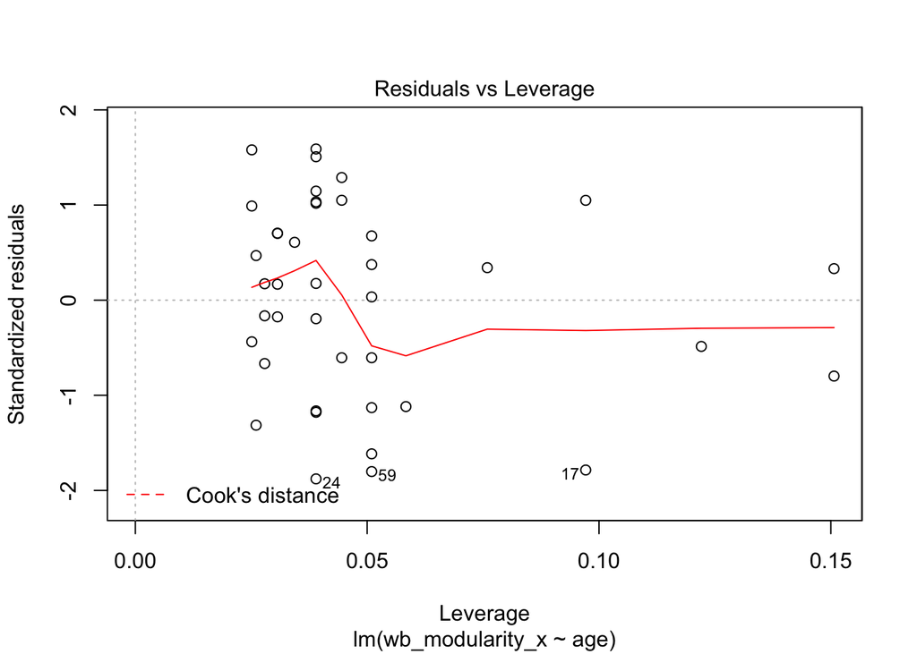

```r
plot(lm1)
```